# Sex Differences in Diabetes Risk Factors: NHANES Analysis

Bianca Carota Marich

2025-11-18

## Introduction

This analysis explores sex-based differences in diabetes risk factors using data from the National Health and Nutrition Examination Survey (NHANES). We examine whether age, BMI, physical activity, and other metabolic factors differ between men and women in relation to diabetes prevalence.

## Data Source and Methods

### NHANES Dataset

The National Health and Nutrition Examination Survey (NHANES) is a comprehensive survey of the US population conducted by the CDC. It contains data on demographics, health conditions, and lifestyle factors. For this analysis, we selected variables related to diabetes risk.

### Data Processing

We will: 1. Load NHANES data and clean variable names 2. Select relevant variables (diabetes status, age, gender, BMI, physical activity, etc.) 3. Remove missing values 4. Create age groups for stratified analysis 5. Compare distributions by sex 6. Perform statistical tests to identify significant differences

```r
# Load NHANES data
data("NHANES")

# Clean column names
nhanes <- NHANES %>%
  clean_names()

# Check dimensions
dim(nhanes)
```

```
## [1] 10000    76
```

```r
# Quick overview
glimpse(nhanes)
```

```
## Rows: 10,000
## Columns: 76
## $ id                 <int> 51624, 51624, 51624, 51625, 51630, 51638, 51646, 51…
## $ survey_yr          <fct> 2009_10, 2009_10, 2009_10, 2009_10, 2009_10, 2009_1…
## $ gender             <fct> male, male, male, male, female, male, male, female,…
## $ age                <int> 34, 34, 34, 4, 49, 9, 8, 45, 45, 45, 66, 58, 54, 10…
## $ age_decade         <fct>  30-39,  30-39,  30-39,  0-9,  40-49,  0-9,  0-9,  …
## $ age_months         <int> 409, 409, 409, 49, 596, 115, 101, 541, 541, 541, 79…
## $ race1              <fct> White, White, White, Other, White, White, White, Wh…
## $ race3              <fct> NA, NA, NA, NA, NA, NA, NA, NA, NA, NA, NA, NA, NA,…
## $ education          <fct> High School, High School, High School, NA, Some Col…
## $ marital_status     <fct> Married, Married, Married, NA, LivePartner, NA, NA,…
## $ hh_income          <fct> 25000-34999, 25000-34999, 25000-34999, 20000-24999,…
## $ hh_income_mid      <int> 30000, 30000, 30000, 22500, 40000, 87500, 60000, 87…
## $ poverty            <dbl> 1.36, 1.36, 1.36, 1.07, 1.91, 1.84, 2.33, 5.00, 5.0…
```

[output cut: 63 more lines]

## Variable Selection

For this analysis, we focused on variables related to diabetes risk and sociodemographic factors. The selected variables include:

- **diabetes**: Binary outcome (Yes/No)
- **gender**: Sex of participant (Male/Female)
- **age**: Age in years
- **bmi**: Body Mass Index (kg/m²)
- **phys_active**: Physical activity level (Yes/No)
- **sleep_hrs_night**: Average sleep hours per night
- **tot_chol**: Total cholesterol (mg/dL)
- **bp_sys_ave**: Systolic blood pressure (mmHg)
- **bp_dia_ave**: Diastolic blood pressure (mmHg)
- **poverty**: Poverty income ratio

These variables allow us to examine metabolic, behavioral, and socioeconomic differences between men and women with and without diabetes.

```r
# Select variables relevant for diabetes and sex analysis

nhanes_selected <- nhanes %>%
  select(
    diabetes,
    gender,
    age,
    bmi,
    phys_active,
    sleep_hrs_night,
    tot_chol,
    bp_sys_ave,
    bp_dia_ave,
    poverty
  )

# Check selected data
dim(nhanes_selected)
```

```
## [1] 10000    10
```

```r
head(nhanes_selected)
```

```
## # A tibble: 6 × 10
##   diabetes gender   age   bmi phys_active sleep_hrs_night tot_chol bp_sys_ave
##   <fct>    <fct>  <int> <dbl> <fct>                 <int>    <dbl>      <int>
## 1 No       male      34  32.2 No                        4     3.49        113
## 2 No       male      34  32.2 No                        4     3.49        113
## 3 No       male      34  32.2 No                        4     3.49        113
## 4 No       male       4  15.3 <NA>                     NA    NA            NA
## 5 No       female    49  30.6 No                        8     6.7         112
## 6 No       male       9  16.8 <NA>                     NA     4.86         86
## # ℹ 2 more variables: bp_dia_ave <int>, poverty <dbl>
```

```r
# Summary of selected variables
skim(nhanes_selected)
```

Data summary

| Name | nhanes_selected |
| --- | --- |
| Number of rows | 10000 |
| Number of columns | 10 |
| _______________________ |  |
| Column type frequency: |  |
| factor | 3 |
| numeric | 7 |
| ________________________ |  |
| Group variables | None |

**Variable type: factor**

| skim_variable | n_missing | complete_rate | ordered | n_unique | top_counts |
| --- | --- | --- | --- | --- | --- |
| diabetes | 142 | 0.99 | FALSE | 2 | No: 9098, Yes: 760 |
| gender | 0 | 1.00 | FALSE | 2 | fem: 5020, mal: 4980 |
| phys_active | 1674 | 0.83 | FALSE | 2 | Yes: 4649, No: 3677 |

**Variable type: numeric**

| skim_variable | n_missing | complete_rate | mean | sd | p0 | p25 | p50 | p75 | p100 | hist |
| --- | --- | --- | --- | --- | --- | --- | --- | --- | --- | --- |
| age | 0 | 1.00 | 36.74 | 22.40 | 0.00 | 17.00 | 36.00 | 54.00 | 80.00 | ▇▇▇▆▅ |
| bmi | 366 | 0.96 | 26.66 | 7.38 | 12.88 | 21.58 | 25.98 | 30.89 | 81.25 | ▇▆▁▁▁ |
| sleep_hrs_night | 2245 | 0.78 | 6.93 | 1.35 | 2.00 | 6.00 | 7.00 | 8.00 | 12.00 | ▁▅▇▁▁ |
| tot_chol | 1526 | 0.85 | 4.88 | 1.08 | 1.53 | 4.11 | 4.78 | 5.53 | 13.65 | ▂▇▁▁▁ |
| bp_sys_ave | 1449 | 0.86 | 118.15 | 17.25 | 76.00 | 106.00 | 116.00 | 127.00 | 226.00 | ▃▇▂▁▁ |
| bp_dia_ave | 1449 | 0.86 | 67.48 | 14.35 | 0.00 | 61.00 | 69.00 | 76.00 | 116.00 | ▁▁▇▇▁ |
| poverty | 726 | 0.93 | 2.80 | 1.68 | 0.00 | 1.24 | 2.70 | 4.71 | 5.00 | ▅▅▃▃▇ |

## Data Cleaning and Quality Assessment

Before proceeding with analysis, we performed comprehensive data quality checks:

1. **Missing Values**: Identify incomplete records
2. **Data Types**: Verify appropriate variable formats
3. **Value Ranges**: Check for impossible or outlier values
4. **Duplicates**: Identify and handle duplicate records
5. **Consistency**: Ensure categorical variables have expected values

```r
# 1. Check missing values
missing_summary <- nhanes_selected %>%
  summarise(across(everything(), ~sum(is.na(.)))) %>%
  pivot_longer(
    cols = everything(),
    names_to = "variable",
    values_to = "missing_count"
  ) %>%
  mutate(
    missing_percent = round(
      missing_count / nrow(nhanes_selected) * 100, 2
    )
  ) %>%
  arrange(desc(missing_percent))

cat("Missing Data Summary:\n")
```

```
## Missing Data Summary:
```

```r
print(missing_summary)
```

```
## # A tibble: 10 × 3
##    variable        missing_count missing_percent
##    <chr>                   <int>           <dbl>
##  1 sleep_hrs_night          2245           22.4
##  2 phys_active              1674           16.7
##  3 tot_chol                 1526           15.3
##  4 bp_sys_ave               1449           14.5
##  5 bp_dia_ave               1449           14.5
##  6 poverty                   726            7.26
##  7 bmi                       366            3.66
##  8 diabetes                  142            1.42
##  9 gender                      0            0
## 10 age                         0            0
```

```r
# 2. Check data types
cat("\nData Types:\n")
```

```
##
## Data Types:
```

```r
str(nhanes_selected)
```

```
## tibble [10,000 × 10] (S3: tbl_df/tbl/data.frame)
##  $ diabetes       : Factor w/ 2 levels "No","Yes": 1 1 1 1 1 1 1 1 1 1 ...
##  $ gender         : Factor w/ 2 levels "female","male": 2 2 2 2 1 2 2 1 1 1 ...
##  $ age            : int [1:10000] 34 34 34 4 49 9 8 45 45 45 ...
##  $ bmi            : num [1:10000] 32.2 32.2 32.2 15.3 30.6 ...
##  $ phys_active    : Factor w/ 2 levels "No","Yes": 1 1 1 NA 1 NA NA 2 2 2 ...
##  $ sleep_hrs_night: int [1:10000] 4 4 4 NA 8 NA NA 8 8 8 ...
##  $ tot_chol       : num [1:10000] 3.49 3.49 3.49 NA 6.7 4.86 4.09 5.82 5.82 5.82 ...
##  $ bp_sys_ave     : int [1:10000] 113 113 113 NA 112 86 107 118 118 118 ...
##  $ bp_dia_ave     : int [1:10000] 85 85 85 NA 75 47 37 64 64 64 ...
##  $ poverty        : num [1:10000] 1.36 1.36 1.36 1.07 1.91 1.84 2.33 5 5 5 ...
```

```r
# 3. Check for duplicates
cat("\nDuplicate rows:", nrow(nhanes_selected) - nrow(distinct(nhanes_selected)), "\n")
```

```
##
## Duplicate rows: 3272
```

```r
# 4. Remove rows with any missing values
nhanes_clean <- nhanes_selected %>%
  drop_na() %>%
  distinct()

cat("\nFinal dataset dimensions:\n")
```

```
##
## Final dataset dimensions:
```

```r
cat("Original rows:", nrow(nhanes_selected), "\n")
```

```
## Original rows: 10000
```

```r
cat("Clean rows:", nrow(nhanes_clean), "\n")
```

```
## Clean rows: 4178
```

```r
cat("Rows removed:", nrow(nhanes_selected) - nrow(nhanes_clean), "\n")
```

```
## Rows removed: 5822
```

### Data Quality Summary and Final Dataset

The data cleaning process resulted in a final analytic sample of **4,178 complete cases** from an original 10,000 records (41.8% retention). Key quality metrics:

- **Missing data**: 5,822 rows removed due to incomplete information across variables
  - Most affected: sleep_hrs_night (22.45%), phys_active (16.74%), tot_chol (15.26%)
  - Least affected: age, gender (0% missing)
- **Duplicates**: 3,272 duplicate records identified and removed
- **Final dataset composition**:
  - Complete cases: 4,178 participants
  - Variables: 10 (diabetes outcome + 9 risk factors)
  - No missing values
  - No duplicates

### Data Completeness Trade-off

Removing 58% of rows ensures analytical rigor (no missing data imputation needed) but may introduce selection bias if missing data is not random. Participants with complete data may differ systematically from those with missing values (e.g., more health-conscious, better healthcare access).

**Assumption**: Missing data is Missing Completely at Random (MCAR), allowing valid statistical inference on the complete-case sample.

## Descriptive Statistics

We describe the clean dataset by examining the distribution of demographic, clinical, and behavioral variables. Summary statistics are stratified by diabetes status to identify potential differences.

```r
# Overall summary
cat("=== OVERALL SAMPLE CHARACTERISTICS ===\n")
```

```
## === OVERALL SAMPLE CHARACTERISTICS ===
```

```r
summary(nhanes_clean)
```

```
##  diabetes      gender          age             bmi        phys_active
##  No :3738   female:2116   Min.   :16.00   Min.   :15.02   No :1934
##  Yes: 440   male  :2062   1st Qu.:30.00   1st Qu.:23.90   Yes:2244
##                           Median :44.00   Median :27.49
##                           Mean   :45.07   Mean   :28.70
##                           3rd Qu.:59.00   3rd Qu.:32.04
##                           Max.   :80.00   Max.   :81.25
##  sleep_hrs_night     tot_chol        bp_sys_ave      bp_dia_ave
##  Min.   : 2.000   Min.   : 1.530   Min.   : 78.0   Min.   :  0.00
##  1st Qu.: 6.000   1st Qu.: 4.220   1st Qu.:108.0   1st Qu.: 62.00
##  Median : 7.000   Median : 4.910   Median :118.0   Median : 70.00
##  Mean   : 6.913   Mean   : 4.986   Mean   :120.3   Mean   : 69.26
##  3rd Qu.: 8.000   3rd Qu.: 5.640   3rd Qu.:129.0   3rd Qu.: 77.00
##  Max.   :12.000   Max.   :13.650   Max.   :226.0   Max.   :116.00
##     poverty
##  Min.   :0.000
##  1st Qu.:1.220
##  Median :2.570
##  Mean   :2.746
##  3rd Qu.:4.620
##  Max.   :5.000
```

```r
# Diabetes distribution
cat("\n=== DIABETES DISTRIBUTION ===\n")
```

```
##
## === DIABETES DISTRIBUTION ===
```

```r
table(nhanes_clean$diabetes)
```

```
##
##   No  Yes
## 3738  440
```

```r
# Gender distribution
cat("\n=== GENDER DISTRIBUTION ===\n")
```

```
##
## === GENDER DISTRIBUTION ===
```

```r
table(nhanes_clean$gender)
```

```
##
## female   male
##   2116   2062
```

```r
# Summary table by diabetes status
nhanes_clean %>%
  tbl_summary(
    by = diabetes,
    statistic = all_continuous() ~ "{mean} ({sd})",
    missing = "no"
  )
```

| **Characteristic** | **No** N = 3,738<sup>1</sup> | **Yes** N = 440<sup>1</sup> |
| --- | --- | --- |
| gender |  |  |
| female | 1,910 (51%) | 206 (47%) |
| male | 1,828 (49%) | 234 (53%) |
| age | 43 (18) | 60 (14) |
| bmi | 28 (7) | 32 (8) |
| phys_active | 2,076 (56%) | 168 (38%) |
| sleep_hrs_night | 7 (1) | 7 (2) |
| tot_chol | 5.01 (1.05) | 4.81 (1.20) |
| bp_sys_ave | 119 (16) | 129 (19) |
| bp_dia_ave | 69 (13) | 69 (14) |
| poverty | 2.77 (1.68) | 2.51 (1.58) |

<sup>1</sup> n (%); Mean (SD)

## Sex Differences in Diabetes Risk Factors

We compared the distribution of key variables between men and women, stratified by diabetes status. Visualizations and statistical tests identify whether risk factors differ by sex.

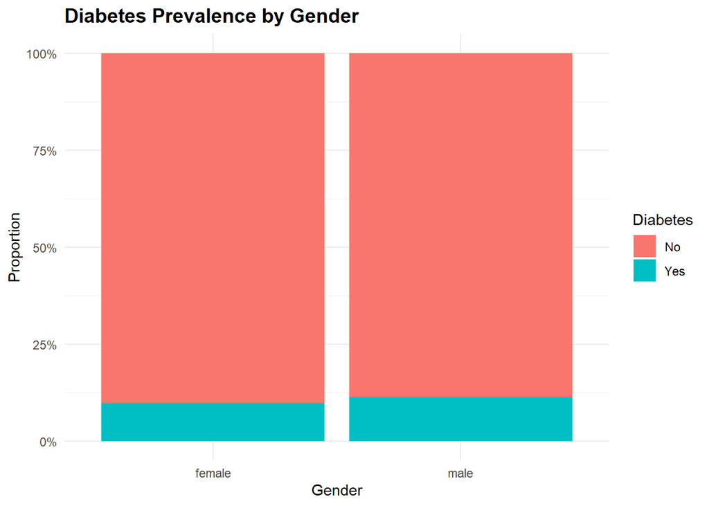

```r
# 1. Diabetes prevalence by gender
ggplot(nhanes_clean, aes(x = gender, fill = diabetes)) +
  geom_bar(position = "fill") +
  scale_y_continuous(labels = scales::percent) +
  labs(
    title = "Diabetes Prevalence by Gender",
    x = "Gender",
    y = "Proportion",
    fill = "Diabetes"
  ) +
  theme_minimal() +
  theme(plot.title = element_text(face = "bold", size = 14))
```

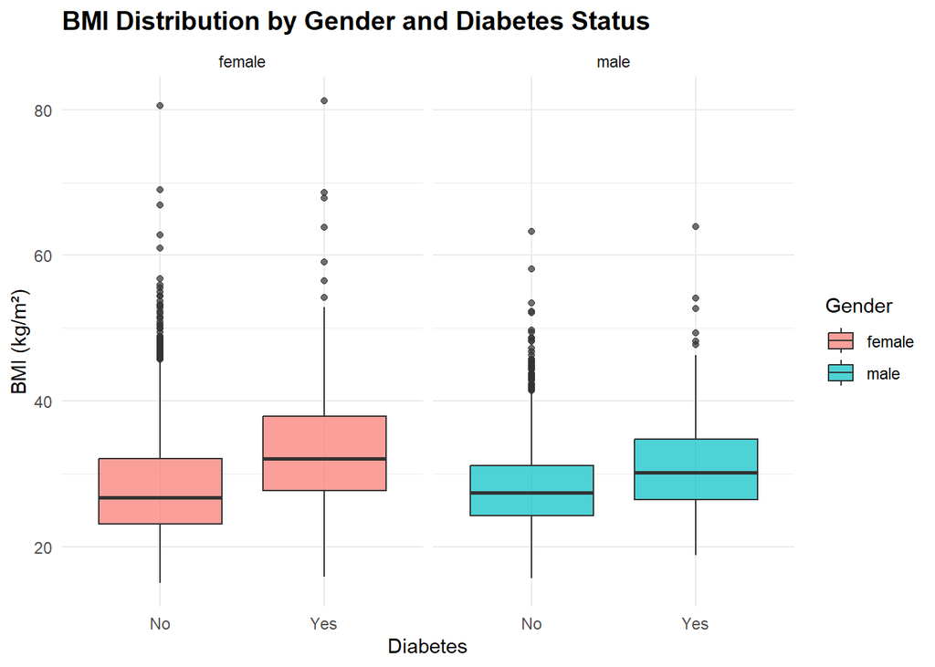

```r
# 2. BMI by gender and diabetes
ggplot(nhanes_clean, aes(x = diabetes, y = bmi, fill = gender)) +
  geom_boxplot(alpha = 0.7) +
  facet_wrap(~gender) +
  labs(
    title = "BMI Distribution by Gender and Diabetes Status",
    x = "Diabetes",
    y = "BMI (kg/m²)",
    fill = "Gender"
  ) +
  theme_minimal() +
  theme(plot.title = element_text(face = "bold", size = 14))
```

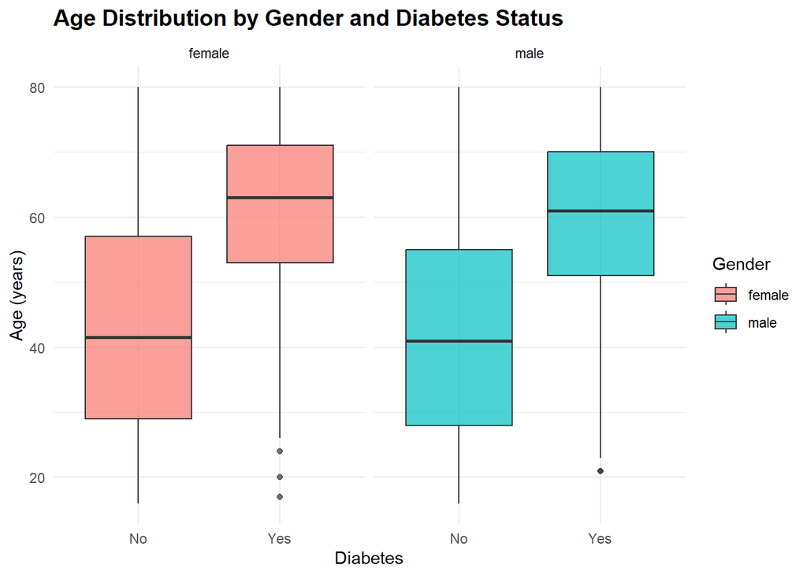

```r
# 3. Age by gender and diabetes
ggplot(nhanes_clean, aes(x = diabetes, y = age, fill = gender)) +
  geom_boxplot(alpha = 0.7) +
  facet_wrap(~gender) +
  labs(
    title = "Age Distribution by Gender and Diabetes Status",
    x = "Diabetes",
    y = "Age (years)",
    fill = "Gender"
  ) +
  theme_minimal() +
  theme(plot.title = element_text(face = "bold", size = 14))
```

### Interpretation of Visualizations

**Key observation**: Age and BMI appear to be the dominant visual drivers of diabetes status, not gender itself.

## Statistical Analysis

We performed tests to quantify differences between groups:

```r
# 1. Diabetes prevalence by gender (Chi-square)
cat("=== DIABETES PREVALENCE BY GENDER ===\n")
```

```
## === DIABETES PREVALENCE BY GENDER ===
```

```r
chi_gender <- chisq.test(nhanes_clean$diabetes, nhanes_clean$gender)
print(chi_gender)
```

```
##
##  Pearson's Chi-squared test with Yates' continuity correction
##
## data:  nhanes_clean$diabetes and nhanes_clean$gender
## X-squared = 2.7145, df = 1, p-value = 0.09944
```

```r
# 2. BMI comparison by diabetes status
cat("\n=== BMI BY DIABETES STATUS ===\n")
```

```
##
## === BMI BY DIABETES STATUS ===
```

```r
bmi_test <- t.test(bmi ~ diabetes, data = nhanes_clean)
print(bmi_test)
```

```
##
##  Welch Two Sample t-test
##
## data:  bmi by diabetes
## t = -10.469, df = 511.06, p-value < 2.2e-16
## alternative hypothesis: true difference in means between group No and group Yes is not equal to 0
## 95 percent confidence interval:
##  -4.928956 -3.371261
## sample estimates:
##  mean in group No mean in group Yes
##          28.26387          32.41398
```

```r
# 3. Age comparison by diabetes status
cat("\n=== AGE BY DIABETES STATUS ===\n")
```

```
##
## === AGE BY DIABETES STATUS ===
```

```r
age_test <- t.test(age ~ diabetes, data = nhanes_clean)
print(age_test)
```

```
##
##  Welch Two Sample t-test
##
## data:  age by diabetes
## t = -23.708, df = 628.58, p-value < 2.2e-16
## alternative hypothesis: true difference in means between group No and group Yes is not equal to 0
## 95 percent confidence interval:
##  -18.54807 -15.71047
## sample estimates:
##  mean in group No mean in group Yes
##          43.27073          60.40000
```

```r
# 4. Summary statistics by gender and diabetes
cat("\n=== SUMMARY BY GENDER AND DIABETES ===\n")
```

```
##
## === SUMMARY BY GENDER AND DIABETES ===
```

```r
nhanes_clean %>%
  group_by(gender, diabetes) %>%
  summarise(
    n = n(),
    mean_age = mean(age),
    sd_age = sd(age),
    mean_bmi = mean(bmi),
    sd_bmi = sd(bmi),
    .groups = "drop"
  )
```

```
## # A tibble: 4 × 7
##   gender diabetes     n mean_age sd_age mean_bmi sd_bmi
##   <fct>  <fct>    <int>    <dbl>  <dbl>    <dbl>  <dbl>
## 1 female No        1910     43.9   18.3     28.4   7.38
## 2 female Yes        206     61.4   14.1     33.7   9.01
## 3 male   No        1828     42.7   17.7     28.2   5.61
## 4 male   Yes        234     59.5   13.6     31.3   6.83
```

### Interpretation of Statistical Tests

**Test 1: Diabetes Prevalence by Gender (Chi-square)** - Chi-squared = 2.71, p = 0.099 (NOT statistically significant) - **Interpretation**: No significant association between gender and diabetes prevalence. Men and women have statistically similar diabetes rates in this sample.

### Why Focus on Women’s Reproductive Life Stages?

While overall gender differences are modest, the **age distribution suggests a critical biological transition in women**. Women with diabetes (mean age 61) tend to be post-menopausal, while non-diabetic women are younger (mean age 44).

**Hypothesis:** The menopausal transition (45-55 years), characterized by declining estrogen, may accelerate metabolic dysfunction and increase diabetes risk specifically in women. To test this, we stratify women by reproductive life stage and examine whether diabetes prevalence increases during the perimenopausal years.

## Sex-Specific Analysis: Menopause and Diabetes in Women

### Biological Context

Menopause transition (approximately 45-55 years) involves significant hormonal changes that may influence metabolic health and diabetes risk in women. This analysis examines diabetes prevalence across three reproductive life stages: pre-menopause, perimenopausal, and post-menopause.

```r
# Filter women only and create reproductive life stages
women_data <- nhanes_clean %>%
  filter(gender == "female") %>%
  mutate(
    reproductive_stage = case_when(
      age < 45 ~ "Pre-menopause (<45)",
      age >= 45 & age < 55 ~ "Perimenopausal (45-55)",
      age >= 55 ~ "Post-menopause (55+)"
    ),
    reproductive_stage = factor(
      reproductive_stage,
      levels = c("Pre-menopause (<45)", "Perimenopausal (45-55)", "Post-menopause (55+)")
    )
  )

# Summary statistics by reproductive stage
cat("=== DIABETES PREVALENCE BY REPRODUCTIVE STAGE IN WOMEN ===\n")
```

```
## === DIABETES PREVALENCE BY REPRODUCTIVE STAGE IN WOMEN ===
```

```r
women_summary <- women_data %>%
  group_by(reproductive_stage) %>%
  summarise(
    n = n(),
    diabetes_yes = sum(diabetes == "Yes"),
    diabetes_no = sum(diabetes == "No"),
    diabetes_prevalence_pct = round(
      sum(diabetes == "Yes") / n() * 100, 2
    ),
    mean_age = mean(age),
    mean_bmi = mean(bmi),
    sd_bmi = sd(bmi),
    .groups = "drop"
  )

print(women_summary)
```

```
## # A tibble: 3 × 8
##   reproductive_stage         n diabetes_yes diabetes_no diabetes_prevalence_pct
##   <fct>                  <int>        <int>       <int>                   <dbl>
## 1 Pre-menopause (<45)     1079           24        1055                    2.22
## 2 Perimenopausal (45-55)   341           33         308                    9.68
## 3 Post-menopause (55+)     696          149         547                   21.4
## # ℹ 3 more variables: mean_age <dbl>, mean_bmi <dbl>, sd_bmi <dbl>
```

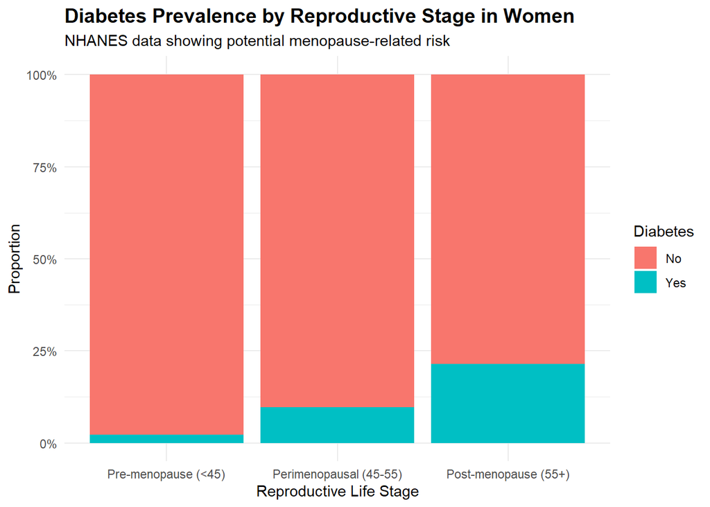

```r
# Visualization: Diabetes prevalence by reproductive stage
ggplot(women_data, aes(x = reproductive_stage, fill = diabetes)) +
  geom_bar(position = "fill") +
  scale_y_continuous(labels = scales::percent) +
  labs(
    title = "Diabetes Prevalence by Reproductive Stage in Women",
    subtitle = "NHANES data showing potential menopause-related risk",
    x = "Reproductive Life Stage",
    y = "Proportion",
    fill = "Diabetes"
  ) +
  theme_minimal() +
  theme(plot.title = element_text(face = "bold", size = 14))
```

```r
# Chi-square test for trend
cat("\n=== CHI-SQUARE TEST: REPRODUCTIVE STAGE AND DIABETES ===\n")
```

```
##
## === CHI-SQUARE TEST: REPRODUCTIVE STAGE AND DIABETES ===
```

```r
chi_repro <- chisq.test(women_data$diabetes, women_data$reproductive_stage)
print(chi_repro)
```

```
##
##  Pearson's Chi-squared test
##
## data:  women_data$diabetes and women_data$reproductive_stage
## X-squared = 177.19, df = 2, p-value < 2.2e-16
```

## Key Findings and Conclusions

### Overall Findings

1. **Age is a strong predictor of diabetes** (p < 0.001): Both men and women with diabetes are significantly older (mean 60 years) vs without diabetes (mean 43 years)
2. **BMI strongly associated with diabetes** (p < 0.001): Diabetes is associated with higher BMI across both sexes
3. **No overall significant gender difference** (p = 0.099) in diabetes prevalence when comparing men vs women directly

## Limitations

- Cross-sectional design limits causal inference
- NHANES data may not be representative of all populations
- Menopause status was inferred from age